# Packaging up the non-inferiority function

Laura Hatfield

2024-12-11

To incorporate the fast matrix multiplication in C++, I used `RcppEigen`, which has a `package.skeleton` function that sets up the infrastructure for the package. I believe the only `fixest` (for model fitting) and `collapse` (for fast subsettting) are the remaining package dependencies.

## Data for testing and vignettes

To get started, I used a dataset distributed in the `did` package, which is county-year observations of teen unemployment and state minimum wage changes from 2003-2007. Since several happened in 2006, I limit the data to only those states (and the never-treated) so we have a common adoption time.

I want a discrete covariate to demonstrate the covariate-specific linear trends model, so I dichotomize the log population to get a binary indicator of “big” counties. I also subtract log population off the log teen unemployment to get a log ratio, otherwise, the two are highly correlated.

I fit a base model with year and county fixed effects plus the interaction term for treated post-period observations. The expanded models add a treatment-group-specific linear trend, a linear trend for large counties, unit-specific linear trends, treatment-group-specific year fixed effects, and separate year fixed effects for large counties. These are the five expanded models in our paper’s Table 1. These are using heteroskedasticity-robust standard errors (the function default) and standard errors clustered at the county level (no weights).

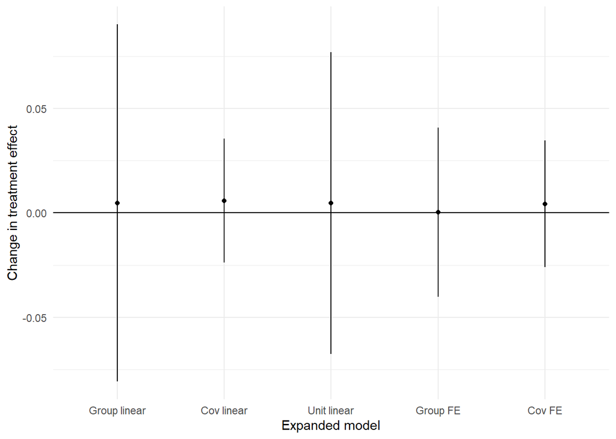

## Using Akosa Antwi data

Now I do the same thing for the Akosa Antwi data we used in the paper. I used the model specification that omits the unemployment controls, but has age, sex, race/ethnicity, and unit and month fixed effects with a treatment effect for the implementation (not enactment) period only. The expanded models are as above, where for an example covariate I use the indicators for the young and old controls. Not sure if this really makes the points we want. These are using heteroskedasticity-robust standard errors (the function default) and standard errors clustered at the county level with survey weights.

Here are the estimates and confidence intervals for the difference between the expanded and reduced models’ treatment effects. The horizontal lines indicate the non-inferiority/equivalence bounds we use in our paper’s Table 4. I think these results replicate what have in that table for the difference between the original and ‘+ trend’ models, which is the same as “Group linear” in these plots. Something doesn’t look right with the “Unit linear” results; I need to think more about why this might be over-specified or something?

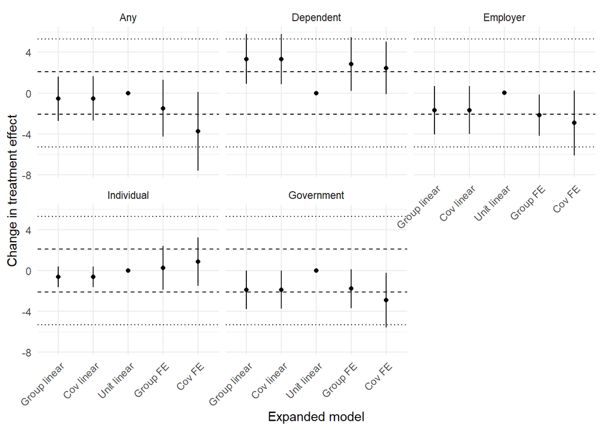

Let’s also look at the treatment effects.

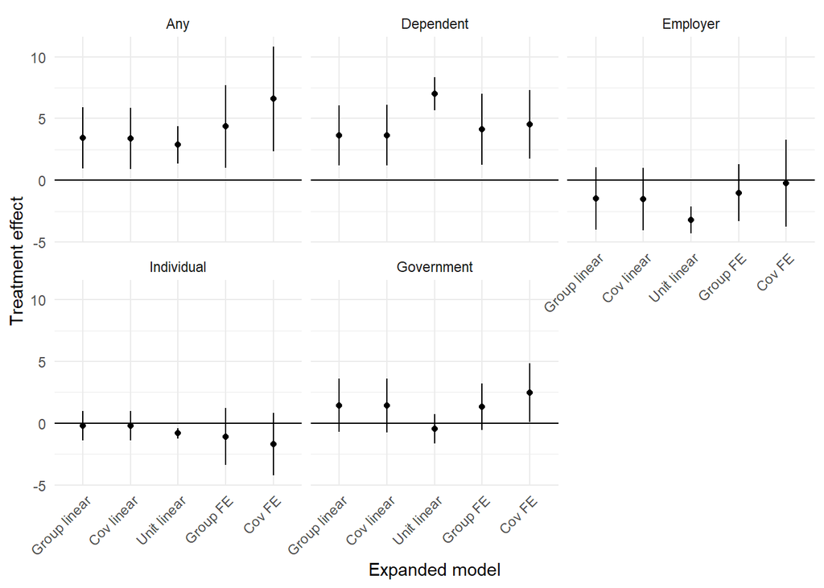